# pizza_challange

```python
import pandas as pd
import numpy as np
import matplotlib.pyplot as plt

train_data=pd.read_json("C:\\Users\\Michael\\PycharmProjects\\pizza_challange\\train.json")
nrow, ncol = train_data.shape
print (nrow," rows", ncol, " cols")
```

```
4040  rows 32  cols
```

```python
# sanity check
with open("C:\\Users\\Michael\\PycharmProjects\\pizza_challange\\train.json") as fh:
    print(len((fh.read().split("giver_username_if_known")))-1)
```

```
4040
```

```python
def sem_2(x):
    """ 2 S.E.M for binary data (sum of data x has 1 S.D. of its sqrt)"""
    if type(x) == pd.core.groupby.groupby.SeriesGroupBy:
        return 2*np.sqrt(x.mean()/x.size())
    return 2*np.sqrt(x.mean()/len(x))
```

```python
train_data.isna().sum(axis=0)
```

```
giver_username_if_known                                    0
number_of_downvotes_of_request_at_retrieval                0
number_of_upvotes_of_request_at_retrieval                  0
post_was_edited                                            0
request_id                                                 0
request_number_of_comments_at_retrieval                    0
request_text                                               0
request_text_edit_aware                                    0
request_title                                              0
requester_account_age_in_days_at_request                   0
requester_account_age_in_days_at_retrieval                 0
requester_days_since_first_post_on_raop_at_request         0
requester_days_since_first_post_on_raop_at_retrieval       0
requester_number_of_comments_at_request                    0
requester_number_of_comments_at_retrieval                  0
requester_number_of_comments_in_raop_at_request            0
requester_number_of_comments_in_raop_at_retrieval          0
requester_number_of_posts_at_request                       0
requester_number_of_posts_at_retrieval                     0
requester_number_of_posts_on_raop_at_request               0
requester_number_of_posts_on_raop_at_retrieval             0
requester_number_of_subreddits_at_request                  0
requester_received_pizza                                   0
requester_subreddits_at_request                            0
requester_upvotes_minus_downvotes_at_request               0
requester_upvotes_minus_downvotes_at_retrieval             0
requester_upvotes_plus_downvotes_at_request                0
requester_upvotes_plus_downvotes_at_retrieval              0
requester_user_flair                                    3046
requester_username                                         0
unix_timestamp_of_request                                  0
unix_timestamp_of_request_utc                              0
dtype: int64
```

```python
train_data["requester_received_pizza"].unique() # good
```

```
array([False,  True])
```

```python
overall_success = train_data["requester_received_pizza"].mean()
uncert = sem_2(train_data["requester_received_pizza"])
print("pizza chance:",'%.3f' % overall_success, "+-",'%.3f' %uncert,"2 S.E.M")
```

```
pizza chance: 0.246 +- 0.016 2 S.E.M
```

# Rules:

### Account >= 90 days

### Karma >= 400

### Delay time between requests

```python
# fraction <90d old account
account_less_than_90_days_old = (train_data["requester_account_age_in_days_at_request"] < 90.)
account_less_than_90_days_old.mean()
```

```
0.40024752475247527
```

```python
account_karma_less_than_400 = train_data["requester_upvotes_minus_downvotes_at_request"]< 400
account_karma_less_than_400.mean()
```

```
0.5955445544554455
```

most requesters do not follow the rules

```python
train_data["requester_does_not_follow_rules"]=(account_karma_less_than_400|account_less_than_90_days_old)
train_data["requester_does_not_follow_rules"].mean()
```

```
0.624009900990099
```

```python
train_data.loc[account_less_than_90_days_old,"requester_received_pizza"].mean()
# not adhering to rules does not prevent pizza gains
```

```
0.21521335807050093
```

Let's check if there is a strong jump in chance at 90 days account age

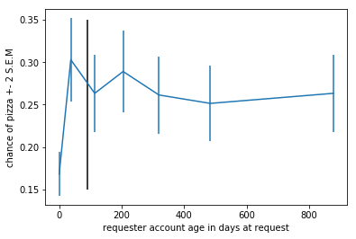

```python
x=train_data["requester_account_age_in_days_at_request"].groupby(by=pd.qcut(train_data["requester_account_age_in_days_at_request"],q=8,duplicates='drop')).mean()
y=train_data["requester_received_pizza"].groupby(by=pd.qcut(train_data["requester_account_age_in_days_at_request"],q=8,duplicates='drop')).mean()
err_y=sem_2(train_data["requester_received_pizza"].groupby(by=pd.qcut(train_data["requester_account_age_in_days_at_request"],q=8,duplicates='drop')))

plt.errorbar(np.array(x), np.array(y), yerr=np.array(err_y))
plt.vlines([90],0.15,0.35)
plt.xlabel("requester account age in days at request")
plt.ylabel("chance of pizza +- 2 S.E.M")
plt.show()
```

account age more or less unimportant unless very young (< ca. 40 days)

how about user karma?

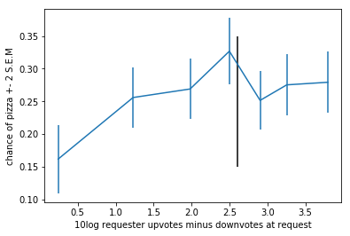

```python
train_data.loc[account_karma_less_than_400,"requester_received_pizza"].mean()
# not adhering to the rules is not problematic


x=train_data["requester_upvotes_minus_downvotes_at_request"].groupby(by=pd.qcut(train_data["requester_upvotes_minus_downvotes_at_request"],q=8,duplicates='drop')).mean()
y=train_data["requester_received_pizza"].groupby(by=pd.qcut(train_data["requester_upvotes_minus_downvotes_at_request"],q=8,duplicates='drop')).mean()
err_y=sem_2(train_data["requester_received_pizza"].groupby(by=pd.qcut(train_data["requester_upvotes_minus_downvotes_at_request"],q=8,duplicates='drop')))

plt.errorbar(np.log10(np.array(x)), np.array(y), yerr=np.array(err_y))
plt.vlines([np.log10(400)],0.15,0.35)
plt.xlabel("10log requester upvotes minus downvotes at request")
plt.ylabel("chance of pizza +- 2 S.E.M")

plt.show()
```

for karma < 10 odds are lower but otherwise not. The 400 karma rule is not reflected here either.

how about the rule on repeat submissions? Are there any?

```python
train_data["requester_username"].is_unique
```

```
True
```

Strange, rules (even if they are not adhered to, c.f. above) allow multiple tries

# Text and title length

First lets generate some derivative text features

```python
import re

# make text lowercase
train_data["request_text_lower"]=train_data["request_text_edit_aware"].apply(lambda x: x.lower())

# split into sentences
train_data["request_text_sentences"]=train_data["request_text_lower"].apply(lambda text:
                                                                          [x for x in re.split("[\n\.]+",text) if len(x)>0])
# split into words
train_data["request_text_words"]=train_data["request_text_sentences"].apply(lambda sentences: " ".join(sentences).split())

# make title lowercase
train_data["request_title_lower"]=train_data["request_title"].apply(lambda x: x.lower())

# split title into sentences
train_data["request_title_sentences"]=train_data["request_title_lower"].apply(lambda text:
                                                                          [x for x in re.split("[\n\.]+",text) if len(x)>0])
# split title into words
train_data["request_title_words"]=train_data["request_title_sentences"].apply(lambda sentences: " ".join(sentences).split())
```

```python
train_data["request_text_n_letter"]=train_data["request_text_lower"].apply(len)
train_data["request_text_n_sentences"]=train_data["request_text_sentences"].apply(len)
train_data["request_text_n_words"]=train_data["request_text_words"].apply(len)
train_data["request_title_n_letter"]=train_data["request_title_lower"].apply(len)
train_data["request_title_n_sentences"]=train_data["request_title_sentences"].apply(len)
train_data["request_title_n_words"]=train_data["request_title_words"].apply(len)
```

```python
train_data[["requester_received_pizza",
           "request_text_n_letter",
           "request_text_n_sentences",
           "request_text_n_words"]].astype(float).corr()
```

|  | requester_received_pizza | request_text_n_letter | request_text_n_sentences | request_text_n_words |
| --- | --- | --- | --- | --- |
| requester_received_pizza | 1.000000 | 0.115881 | 0.122841 | 0.114135 |
| request_text_n_letter | 0.115881 | 1.000000 | 0.874246 | 0.996422 |
| request_text_n_sentences | 0.122841 | 0.874246 | 1.000000 | 0.861868 |
| request_text_n_words | 0.114135 | 0.996422 | 0.861868 | 1.000000 |

Good correlation between text length parameters and pizza chance (but almost perfect correlations between text parameters)

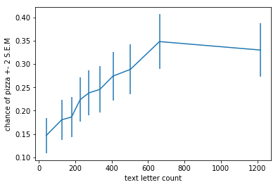

```python
import matplotlib.pyplot as plt

x=train_data["request_text_n_letter"].groupby(by=pd.qcut(train_data["request_text_n_letter"],q=10)).mean()
y=train_data["requester_received_pizza"].groupby(by=pd.qcut(train_data["request_text_n_letter"],q=10)).mean()
err_y=sem_2((train_data["requester_received_pizza"].groupby(by=pd.qcut(train_data["request_text_n_letter"],q=10))))

plt.errorbar(np.array(x), np.array(y), yerr=np.array(err_y))
plt.xlabel("text letter count")
plt.ylabel("chance of pizza +- 2 S.E.M")
plt.show()
```

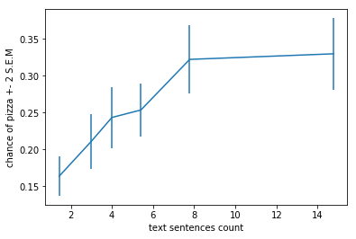

```python
import matplotlib.pyplot as plt

x=train_data["request_text_n_sentences"].groupby(by=pd.qcut(train_data["request_text_n_sentences"],q=6)).mean()
y=train_data["requester_received_pizza"].groupby(by=pd.qcut(train_data["request_text_n_sentences"],q=6)).mean()
err_y=sem_2(train_data["requester_received_pizza"].groupby(by=pd.qcut(train_data["request_text_n_sentences"],q=6)))

plt.errorbar(np.array(x), np.array(y), yerr=np.array(err_y))
plt.xlabel("text sentences count")
plt.ylabel("chance of pizza +- 2 S.E.M")
plt.show()
```

Lets do the same for title metrics

```python
train_data[["requester_received_pizza",
           "request_text_n_letter",
           "request_text_n_sentences",
           "request_text_n_words",
           "request_title_n_letter",
           "request_title_n_sentences",
           "request_title_n_words"]].astype(float).corr()
```

|  | requester_received_pizza | request_text_n_letter | request_text_n_sentences | request_text_n_words | request_title_n_letter | request_title_n_sentences | request_title_n_words |
| --- | --- | --- | --- | --- | --- | --- | --- |
| requester_received_pizza | 1.000000 | 0.115881 | 0.122841 | 0.114135 | 0.014815 | 0.024821 | 0.015680 |
| request_text_n_letter | 0.115881 | 1.000000 | 0.874246 | 0.996422 | -0.034626 | -0.038948 | -0.042360 |
| request_text_n_sentences | 0.122841 | 0.874246 | 1.000000 | 0.861868 | -0.056242 | -0.004938 | -0.060851 |
| request_text_n_words | 0.114135 | 0.996422 | 0.861868 | 1.000000 | -0.039795 | -0.038883 | -0.045244 |
| request_title_n_letter | 0.014815 | -0.034626 | -0.056242 | -0.039795 | 1.000000 | 0.525404 | 0.977201 |
| request_title_n_sentences | 0.024821 | -0.038948 | -0.004938 | -0.038883 | 0.525404 | 1.000000 | 0.506382 |
| request_title_n_words | 0.015680 | -0.042360 | -0.060851 | -0.045244 | 0.977201 | 0.506382 | 1.000000 |

Poor correlations for title metrics. Counterintuitive, lets check the sentence length distribution and plot the effect on pizza chance.

```python
from collections import Counter
Counter(train_data["request_title_n_sentences"])
# ca. 1/3 titles multi sentence: e.g. : '[Request] In Canada (Ontario), just got home from school. Need pizza.'
```

```
Counter({1: 2714, 2: 999, 3: 265, 4: 51, 5: 9, 6: 1, 8: 1})
```

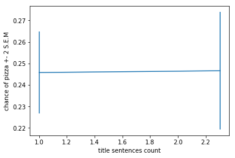

```python
x=train_data["request_title_n_sentences"].groupby(by=train_data["request_title_n_sentences"]>1).mean()
y=train_data["requester_received_pizza"].groupby(by=train_data["request_title_n_sentences"]>1).mean()
err_y=sem_2(train_data["requester_received_pizza"].groupby(by=train_data["request_title_n_sentences"]>1))

plt.errorbar(np.array(x), np.array(y), yerr=np.array(err_y))
plt.xlabel("title sentences count")
plt.ylabel("chance of pizza +- 2 S.E.M")
plt.show()
```

Title sentence count probably insignificant

# average word / sentence length

```python
train_data["request_text_letters_per_word"]=train_data["request_text_n_letter"]/train_data["request_text_n_words"]
train_data["request_title_letters_per_word"]=train_data["request_title_n_letter"]/train_data["request_title_n_words"]
train_data["request_text_words_per_sentence"]=train_data["request_text_n_words"]/train_data["request_text_n_sentences"]
train_data["request_title_words_per_sentence"]=train_data["request_title_n_letter"]/train_data["request_title_n_sentences"]

train_data[["requester_received_pizza",
          "request_text_letters_per_word",
          "request_title_letters_per_word",
          "request_text_words_per_sentence",
          "request_title_words_per_sentence"]].astype(float).corr()
```

|  | requester_received_pizza | request_text_letters_per_word | request_title_letters_per_word | request_text_words_per_sentence | request_title_words_per_sentence |
| --- | --- | --- | --- | --- | --- |
| requester_received_pizza | 1.000000 | -0.017723 | -0.030753 | -0.005462 | 0.000184 |
| request_text_letters_per_word | -0.017723 | 1.000000 | 0.033734 | -0.186041 | 0.045150 |
| request_title_letters_per_word | -0.030753 | 0.033734 | 1.000000 | -0.004666 | -0.227378 |
| request_text_words_per_sentence | -0.005462 | -0.186041 | -0.004666 | 1.000000 | 0.076465 |
| request_title_words_per_sentence | 0.000184 | 0.045150 | -0.227378 | 0.076465 | 1.000000 |

# most common words

```python
from collections import Counter
all_words = [word for list_ in train_data["request_text_words"] for word in list_]
counted_words = Counter(all_words)
top_200_words = sorted(counted_words, key=lambda x:counted_words[x], reverse=True)[:200]
for word in top_200_words:
    print(word, counted_words[word])

# many money related things (also ramen -> 268 counts)
# smilies :) and :(
```

```
i 12001
a 9668
to 9655
and 9614
the 7103
my 6484
of 4745
for 4728
in 4162
have 3323
pizza 3049
it 2812
would 2679
is 2633
but 2522
me 2511
be 2453
i'm 2416
this 2263
on 2256
so 2123
that 1938
if 1896
we 1868
with 1862
you 1812
just 1795
out 1761
get 1745
been 1476
some 1401
can 1339
help 1312
not 1256
at 1253
really 1228
as 1202
are 1196
will 1151
all 1135
```

[output cut: 145 more lines]

```
still 248
student 247
im 244
bank 243
dinner 242
nice 241
hey 241
working 241
living 241
friday 239
things 239
myself 238
rent 233
return 233
friend 231
```

# specific substrings in text

```python
dog_words = ["dog", "pup", "mutt","canine"]
cat_words = ["cat", "kitten","kitty","puss"]
child_words = ["baby","child","kid","son","daughter","infant","teenager","toddler","pregnant","pregger"]
reciprocity_words = ["pay it forward","return the fav"]
hunger_words = ["hungry", "starv","eaten since", "food since",]
money_words = ["pay", "funds", "bills", "afford", "dollar",
               "coin", "the means for", "income", "salary",
               "check","employed", "\$", "poor", "broke", "paid" ]

photos = ["imgur"]
links = ["http"]
# starving is problematic since many say that they are not starving

emoticon_words = ["\:\)", "\:\("]

print("number of requesters using the following word groups:\n")

for word_list, colname in [[dog_words,"contains_dog_words"],
                           [cat_words,"contains_cat_words"],
                           [child_words,"contains_child_words"],
                           [reciprocity_words,"contains_reciprocity_words"],
                           [hunger_words,"contains_hunger_words"],
                           [money_words, "contains_money_words"],
                           [emoticon_words, "contains_emoticon_words"],
                           [photos, "contains_photos"],
                           [links, "contains_links"]]:

    re_string = "|".join(word_list)
    print(re_string)
    train_data[colname] = train_data["request_text_lower"].str.contains(re_string)
    print(train_data[colname].sum())
```

```
number of requesters using the following word groups:

dog|pup|mutt|canine
103
cat|kitten|kitty|puss
416
baby|child|kid|son|daughter|infant|teenager|toddler|pregnant|pregger
742
pay it forward|return the fav
518
hungry|starv|eaten since|food since
592
pay|funds|bills|afford|dollar|coin|the means for|income|salary|check|employed|\$|poor|broke|paid
2175
\:\)|\:\(
450
imgur
163
http
287
```

```python
train_data[["requester_received_pizza",
          "contains_dog_words",
          "contains_cat_words",
          "contains_child_words",
          "contains_reciprocity_words",
          "contains_hunger_words",
          "contains_money_words",
          "contains_emoticon_words",
          "contains_photos",
          "contains_links"]].astype(float).corr()["requester_received_pizza"]
```

```
requester_received_pizza      1.000000
contains_dog_words            0.031567
contains_cat_words            0.040935
contains_child_words          0.067441
contains_reciprocity_words    0.043922
contains_hunger_words         0.002185
contains_money_words          0.095526
contains_emoticon_words       0.029743
contains_photos               0.081473
contains_links                0.067979
Name: requester_received_pizza, dtype: float64
```

Overall posititive correlations with word groups. These are particularly strong with links, photos, children and money words. these do (not shown) correlate well with text lenght as well. Graphs for these are shown below.

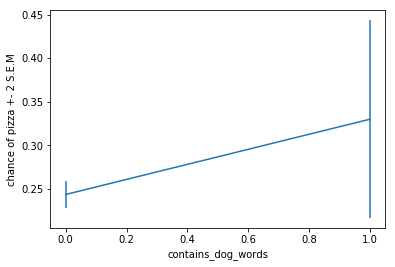

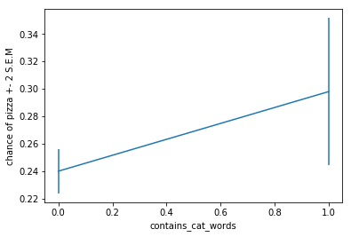

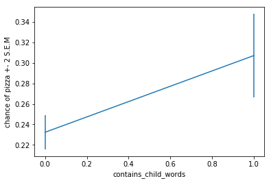

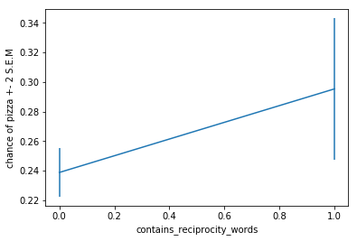

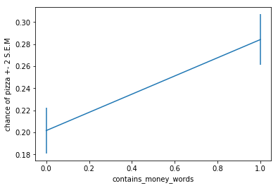

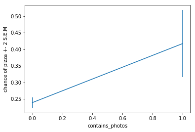

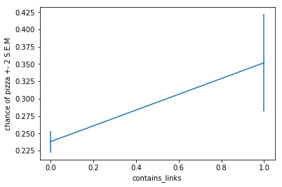

```python
for wordtest in  ["contains_dog_words",
                   "contains_cat_words",
                   "contains_child_words",
                   "contains_reciprocity_words",
                   "contains_money_words",
                   "contains_photos",
                   "contains_links"
                   ]:

    x=train_data[wordtest].groupby(by=train_data[wordtest]).mean()
    y=train_data["requester_received_pizza"].groupby(by=train_data[wordtest]).mean()
    err_y=sem_2(train_data["requester_received_pizza"].groupby(by=train_data[wordtest]))

    plt.errorbar(np.array(x), np.array(y), yerr=np.array(err_y))
    plt.xlabel(wordtest)
    plt.ylabel("chance of pizza +- 2 S.E.M")
    plt.show()

# photos, links, money words, child words best predictors
```

# request tag full capitalized

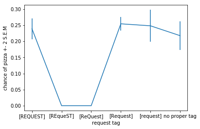

```python
# Request tags usually come as "[request]", "[Request]", and "[REQUEST]" or are not properly tagged. Is there a difference in outcome?
#

train_data["request_tag"] = train_data["request_title"].str.extract("(\[request\])", flags=re.IGNORECASE, expand=False)
train_data["request_tag"] = train_data["request_tag"].fillna("no proper tag")

y=train_data["requester_received_pizza"].groupby(by=train_data["request_tag"]).mean()
x=y.index.values
err_y=sem_2(train_data["requester_received_pizza"].groupby(by=train_data["request_tag"]))

plt.errorbar(np.array(x), np.array(y), yerr=np.array(err_y))
plt.xlabel("request tag")
plt.ylabel("chance of pizza +- 2 S.E.M")
plt.show()
```

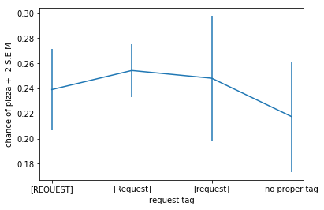

```python
train_data["request_tag"] = train_data["request_title"].str.extract("(\[request\])", flags=re.IGNORECASE, expand=False)
train_data["request_tag"] = train_data["request_tag"].fillna("no proper tag")

y=train_data["requester_received_pizza"].groupby(by=train_data["request_tag"]).mean()
x=y.index.values
err_y=sem_2(train_data["requester_received_pizza"].groupby(by=train_data["request_tag"]))

subset=[0,3,4,5] #do not look at idx 1 and 2 which correspond to weird spellings

plt.errorbar(np.array(x)[subset], np.array(y)[subset], yerr=np.array(err_y)[subset])
plt.xlabel("request tag")
plt.ylabel("chance of pizza +- 2 S.E.M")
plt.show()
```

# Pizza chance over time

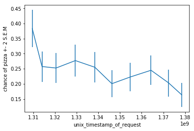

```python
x=train_data["unix_timestamp_of_request"].groupby(by=pd.qcut(train_data["unix_timestamp_of_request"],q=10)).mean()
y=train_data["requester_received_pizza"].groupby(by=pd.qcut(train_data["unix_timestamp_of_request"],q=10)).mean()
err_y=sem_2(train_data["requester_received_pizza"].groupby(by=pd.qcut(train_data["unix_timestamp_of_request"],q=10)))

plt.errorbar(np.array(x), np.array(y), yerr=np.array(err_y))
plt.xlabel("unix_timestamp_of_request")
plt.ylabel("chance of pizza +- 2 S.E.M")
plt.show()
```

Non-linear decrease with time. Subreddit becomes overcrowded/less novel over time leading to fewer pizzas?

# Check title/text for US location

This may be significant due to cultural reasons and user density reasons. Also the presence of a city/state name may help the giver send a pizza.

```python
with open("C:\\Users\Michael\\PycharmProjects\\pizza_challange\\common_US_place_names.txt") as fh:
    list_of_us_placenames = [x.strip() for x in fh.readlines()]

list_of_us_placenames = [re.escape(placename.lower()) for placename in list_of_us_placenames if len(placename) >2 ]# filter out any string that is short
```

```
n US 2033
US combined pizza chance 0.26512543039842595
US title pizza chance 0.2607338017174083
```

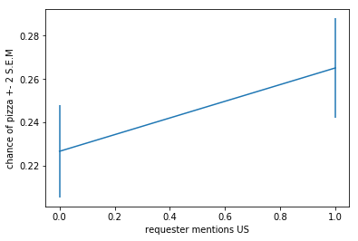

```python
re_us_placenames="|".join(list_of_us_placenames)
# regular expression is slow for this but on this set its OK.
# Otherwise I would check individual words against a set

us_in_title = train_data["request_title_lower"].str.contains(re_us_placenames)
us_in_text = train_data["request_text_lower"].str.contains(re_us_placenames)
train_data["requester from us"] = us_in_title | us_in_text
print("n US",sum(train_data["requester from us"]))
print("US combined pizza chance", train_data.loc[train_data["requester from us"], "requester_received_pizza"].mean())
print("US title pizza chance", train_data.loc[us_in_title, "requester_received_pizza"].mean())

y=train_data["requester_received_pizza"].groupby(by=train_data["requester from us"]).mean()
x = y.index.values
err_y=sem_2(train_data["requester_received_pizza"].groupby(by=train_data["requester from us"]))

plt.errorbar(np.array(x), np.array(y), yerr=np.array(err_y))
plt.xlabel("requester mentions US")
plt.ylabel("chance of pizza +- 2 S.E.M")
plt.show()
```

Statistically significant but small chance offset

# most common subreddits for requesters

```python
from collections import Counter
all_subs = [sub for list_ in train_data["requester_subreddits_at_request"] for sub in list_]
counted_subs = Counter(all_subs)
top_subs_words = sorted(counted_subs.keys(), key=lambda x:counted_subs[x], reverse=True)[:200]
for ix, sub in enumerate(top_subs_words):
    print(ix, sub, counted_subs[sub])
```

```
0 AskReddit 2307
1 pics 1949
2 funny 1932
3 WTF 1515
4 IAmA 1507
5 gaming 1485
6 Random_Acts_Of_Pizza 1413
7 videos 1160
8 todayilearned 1103
9 AdviceAnimals 1021
10 aww 935
11 reddit.com 914
12 trees 874
13 fffffffuuuuuuuuuuuu 874
14 Music 829
```

[output cut: 185 more lines]

Mean pizza rates for subreddit nr 1 - 30:

```
[0.2752492414390984, 0.2775782452539764, 0.27380952380952384, 0.2726072607260726, 0.27405441274054415, 0.27003367003367, 0.2908704883227176, 0.27241379310344827, 0.2728921124206709, 0.23702252693437806, 0.26844919786096255, 0.31291028446389496, 0.26773455377574373, 0.2963386727688787, 0.267792521109…
```

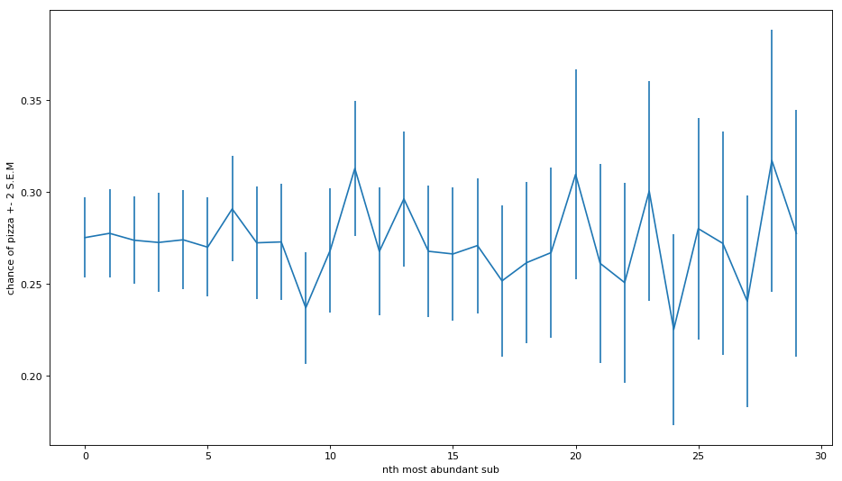

```python
show_n= 30
pizza_score = [train_data.loc[train_data["requester_subreddits_at_request"].apply(lambda x: sub in x),
                  "requester_received_pizza"].mean() for sub in top_subs_words[:show_n]]
print(pizza_score)
piza_score_2_SEM = 2.* np.sqrt(np.array(pizza_score)/np.array([counted_subs[sub] for sub in top_subs_words[:show_n]]))



plt.figure(figsize=(14, 8), dpi= 80, facecolor='w', edgecolor='k')
plt.errorbar(range(show_n),pizza_score[:show_n],piza_score_2_SEM[:show_n])
plt.xlabel("nth most abundant sub")
plt.ylabel("chance of pizza +- 2 S.E.M")
plt.show()
```

Fairly stable chance increase (to ca. 27% chance) for subs except nr 9 /r/AdviceAnimals (lower) and nr 11 /r/reddit.com (higher).

Lets check the number of subreddits requesters interact with.

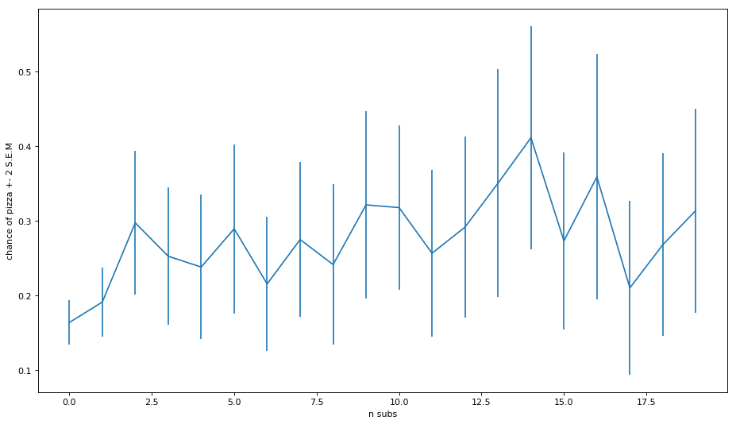

```python
pizza_score = train_data["requester_received_pizza"].groupby(train_data["requester_number_of_subreddits_at_request"]).mean()
piza_score_2_SEM = sem_2(train_data["requester_received_pizza"].groupby(train_data["requester_number_of_subreddits_at_request"]))
x = pizza_score.index.values

pizza_score,piza_score_2_SEM,x = [x[:20] for x in [pizza_score,piza_score_2_SEM,x]]
plt.figure(figsize=(14, 8), dpi= 80, facecolor='w', edgecolor='k')
plt.errorbar(x,pizza_score,piza_score_2_SEM)
plt.xlabel("n subs")
plt.ylabel("chance of pizza +- 2 S.E.M")
plt.show()
```

n_sub >= 2 is clearly more sucessfull than n_sub <2. This graph is noisy due to small binsize so lets check again with larger binsizes.

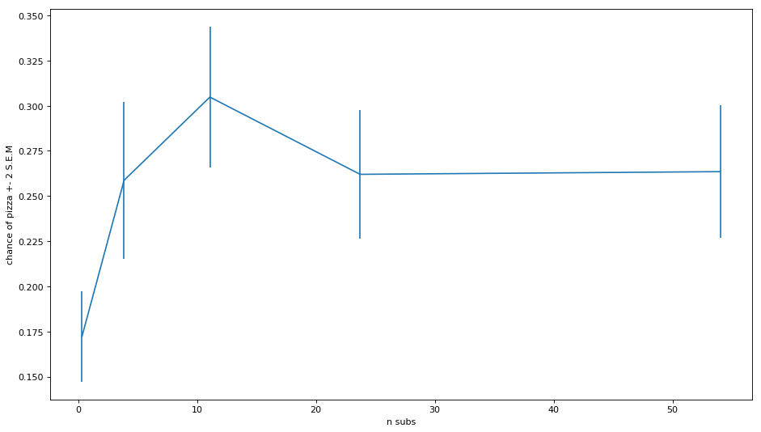

```python
pizza_score = train_data["requester_received_pizza"].groupby(pd.qcut(train_data["requester_number_of_subreddits_at_request"],q=5)).mean()
piza_score_2_SEM = sem_2(train_data["requester_received_pizza"].groupby(pd.qcut(train_data["requester_number_of_subreddits_at_request"],q=5)))
x = train_data["requester_number_of_subreddits_at_request"].groupby(pd.qcut(train_data["requester_number_of_subreddits_at_request"],q=5)).mean()


plt.figure(figsize=(14, 8), dpi= 80, facecolor='w', edgecolor='k')
plt.errorbar(x,pizza_score,piza_score_2_SEM)
plt.xlabel("n subs")
plt.ylabel("chance of pizza +- 2 S.E.M")
plt.show()
```

Pattern holds with larger bins

```python
train_data["requester_less_than_2_subs"] = train_data["requester_number_of_subreddits_at_request"]<2
```

# comments, votes and votes/time -> useless for test data

```python
retrieval_time_days = train_data["requester_account_age_in_days_at_retrieval"] - train_data["requester_account_age_in_days_at_request"]

print(retrieval_time_days.describe())

# enough time has passed for all upvotes to be accumulated. vote/day will not be usefull
#
#
```

```
count    4040.000000
mean      503.106141
std       270.033075
min        45.291562
25%       250.546181
50%       506.368987
75%       761.412052
max      1025.407593
dtype: float64
```

```python
train_data["net_upvotes_of_request_at_retrieval"] =train_data['number_of_upvotes_of_request_at_retrieval']  - train_data["number_of_downvotes_of_request_at_retrieval"]

# make votes / day attributes
train_data['number_of_downvotes_of_request_per_day'] = train_data["number_of_downvotes_of_request_at_retrieval"]/retrieval_time_days
train_data['number_of_upvotes_of_request_per_day'] = train_data["number_of_upvotes_of_request_at_retrieval"]/retrieval_time_days
train_data['net_upvotes_of_request_per_day'] = train_data['number_of_downvotes_of_request_per_day']  - train_data["number_of_upvotes_of_request_at_retrieval"]


train_data[["requester_received_pizza","request_number_of_comments_at_retrieval",'number_of_upvotes_of_request_at_retrieval',"number_of_downvotes_of_request_at_retrieval","net_upvotes_of_request_at_retrieval",'number_of_downvotes_of_request_per_day','number_of_upvotes_of_request_per_day','net_upvotes_of_request_per_day']].astype(float).corr()[["requester_received_pizza","request_number_of_comments_at_retrieval"]]

# net upvotes and number of comments very predictive!
#
# BUT ! May be from after the requester got pizza.
# Also this is not avaialable in the test data so useless
#
```

|  | requester_received_pizza | request_number_of_comments_at_retrieval |
| --- | --- | --- |
| requester_received_pizza | 1.000000 | 0.289153 |
| request_number_of_comments_at_retrieval | 0.289153 | 1.000000 |
| number_of_upvotes_of_request_at_retrieval | 0.102138 | 0.486104 |
| number_of_downvotes_of_request_at_retrieval | 0.026816 | 0.359111 |
| net_upvotes_of_request_at_retrieval | 0.112344 | 0.457339 |
| number_of_downvotes_of_request_per_day | -0.010386 | 0.113828 |
| number_of_upvotes_of_request_per_day | 0.045296 | 0.214816 |
| net_upvotes_of_request_per_day | -0.102219 | -0.486220 |

# Flair? <- useless for test data

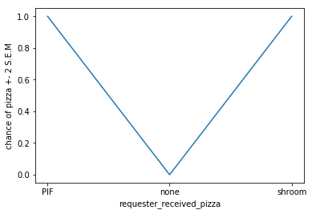

```python
y=train_data["requester_received_pizza"].groupby(train_data["requester_user_flair"].fillna("none")).mean()
x = y.index.values
err_y=2*train_data["requester_received_pizza"].groupby(by=train_data["requester_user_flair"].fillna("none")).sem()
plt.errorbar(np.array(x), np.array(y), yerr=np.array(err_y))
plt.xlabel("requester_received_pizza")
plt.ylabel("chance of pizza +- 2 S.E.M")
plt.show()

#?

# https://www.reddit.com/r/Random_Acts_Of_Pizza/wiki/userflairs:
#
# shroom (received) is someone that has received at least one pizza
# pif and fap (given-received) is someone that has received and given at least once.
#
# still surprising if repeat attempts are present
#
# also flair not present in test set
```

# challenges for predictive model

input is correlated

input - output correlations are non-linear

output classes are unbalanced (25% - 75%)

# Check performance of linear regression as a baseline for performance

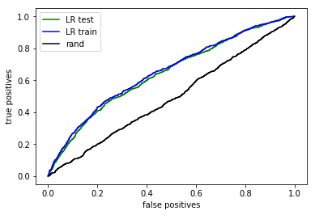

```python
from sklearn.model_selection import KFold
from sklearn.linear_model import LinearRegression
import matplotlib.pyplot  as plt
from sklearn.metrics import roc_curve



xtrain = train_data[["request_text_n_letter",
                     "requester_less_than_2_subs",
                     "contains_dog_words",
                     "contains_cat_words",
                     "contains_child_words",
                     "contains_reciprocity_words",
                     "contains_money_words",
                     "contains_photos",
                     "contains_links",
                     "unix_timestamp_of_request",
                     "requester from us",
                     "requester_does_not_follow_rules"]]

ytrain = train_data["requester_received_pizza"]

rand_f_p, rand_t_p, thresholds  = roc_curve(ytrain, np.random.rand(nrow))

kf = KFold(n_splits=5)

predictions_test  = pd.Series(np.full(nrow, np.nan),index = xtrain.index.values)
predictions_train = pd.Series(np.full(nrow, 0.),index = xtrain.index.values)

for train_index, test_index in kf.split(xtrain.index.values):
    clf = LinearRegression()
    clf.fit(xtrain.loc[train_index],ytrain[train_index])
    predictions_test[test_index] = clf.predict(xtrain.loc[test_index])
    predictions_train[train_index] += clf.predict(xtrain.loc[train_index])*0.25

test_lr_f_p, test_lr_t_p, thresholds = roc_curve(ytrain,predictions_test )
train_lr_f_p, train_lr_t_p, thresholds = roc_curve(ytrain,predictions_train )


plt.plot(test_lr_f_p,test_lr_t_p, c='g')
plt.plot(train_lr_f_p,train_lr_t_p,c="b")
plt.plot(rand_f_p,rand_t_p,c='k')

plt.xlabel("false positives")
plt.ylabel("true positives")
plt.legend(["LR test","LR train","rand"])
```

```python
train_data=train_data.sample(frac=1)
# shuffle just in case
```

# random forrest

Works on non-linear data and correlated nputs

Equal weights will predict very few pizzas:

```python
from sklearn.ensemble import RandomForestClassifier
from sklearn.model_selection import cross_val_score
from sklearn.metrics import confusion_matrix, f1_score


xtrain = train_data[["request_text_n_letter",
                     "requester_number_of_subreddits_at_request",
                     "contains_dog_words",
                     "contains_cat_words",
                     "contains_child_words",
                     "contains_reciprocity_words",
                     "contains_money_words",
                     "contains_photos",
                     "contains_links",
                     "unix_timestamp_of_request",
                     "requester from us",
                     "requester_upvotes_minus_downvotes_at_request",
                     "requester_account_age_in_days_at_request"]]

ytrain = train_data["requester_received_pizza"]




clf = RandomForestClassifier(max_depth=6, class_weight=None,n_estimators =10)

reg = clf.fit(xtrain, ytrain)
y_pred = reg.predict(xtrain)

cm = confusion_matrix(ytrain,y_pred)
print(pd.DataFrame(cm,columns = ["pred no pizza","pred pizza"],index= ["no pizza","pizza"]))
accuracy = (ytrain == y_pred).mean()

print("\naccuracy: ", accuracy)
print("F1: ", f1_score(ytrain,y_pred))
p_np, p_p = (cm*np.eye(2)).sum(1)/cm.sum(1)
print( "\nprecission no pizza", p_np)

clf = RandomForestClassifier(max_depth=6, class_weight=None,n_estimators =10)

reg = clf.fit(xtrain, ytrain)
print( "precission pizza", p_p)
```

```
          pred no pizza  pred pizza
no pizza           3037           9
pizza               905          89

accuracy:  0.7737623762376238
F1:  0.163003663003663

precission no pizza 0.9970453053184505
precission pizza 0.08953722334004025
```

# weights balanced

lower accuracy, higher F1, more pizza predictions

```python
clf = RandomForestClassifier(max_depth=6, class_weight="balanced")

reg = clf.fit(xtrain, ytrain)
y_pred = reg.predict(xtrain)
print(pd.DataFrame(confusion_matrix(ytrain,y_pred),columns = ["pred no pizza","pred pizza"],index= ["no pizza","pizza"]))

accuracy = (ytrain == y_pred).mean()
print("\n accuracy: ", accuracy)
print("       F1: ", f1_score(ytrain,y_pred))
```

```
          pred no pizza  pred pizza
no pizza           2265         781
pizza               377         617

 accuracy:  0.7133663366336633
       F1:  0.5158862876254181
```

# Effect of tree height

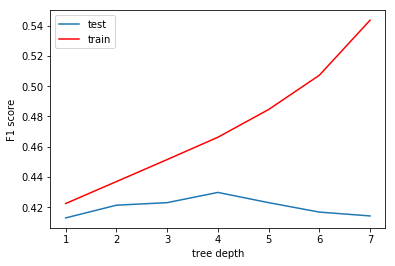

```python
results_test = []
results_train = []

do_x_times = 10

tree_depths = range(1,8)
for max_depth in tree_depths:
    clf = RandomForestClassifier(max_depth=max_depth, class_weight="balanced")
    test_result = np.mean([np.mean(cross_val_score(clf,xtrain, ytrain, scoring='f1', cv=5)) for x in range(do_x_times)])
    results_test.append(test_result)
    train_result = np.mean([ f1_score(clf.fit(xtrain, ytrain).predict(xtrain),ytrain)for x in range(do_x_times)])
    results_train.append(train_result)


plt.plot(tree_depths,results_test)
plt.plot(tree_depths,results_train,c="r")
plt.xlabel("tree depth")
plt.ylabel("F1 score")
plt.legend(["test","train"])
```

depth of ca. 4 optimal. More risks overfitting.

# Effect of forest size

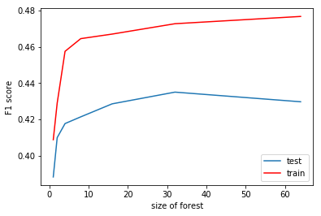

```python
results_test = []
results_train = []

do_x_times = 10

n_estimators = [2**x for x in range(7)]
for n_est in n_estimators:
    clf = RandomForestClassifier(max_depth=4, class_weight="balanced",n_estimators = n_est)
    test_result = np.mean([np.mean(cross_val_score(clf,xtrain, ytrain, scoring='f1', cv=5)) for x in range(do_x_times)])
    results_test.append(test_result)
    train_result = np.mean([ f1_score(clf.fit(xtrain, ytrain).predict(xtrain),ytrain)for x in range(do_x_times)])
    results_train.append(train_result)


plt.plot(n_estimators,results_test)
plt.plot(n_estimators,results_train,c="r")
plt.ylabel("F1 score")
plt.xlabel("size of forest")
plt.legend(["test","train"])
```

Test does well at ca. 30 trees

# False positive <> true positives curve

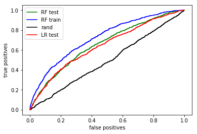

```python
from sklearn.model_selection import KFold

kf = KFold(n_splits=5)

predictions_test  = pd.Series(np.full(nrow, np.nan),index = xtrain.index.values)
predictions_train = pd.Series(np.full(nrow, 0.),index = xtrain.index.values)

for train_index, test_index in kf.split(xtrain.index.values):
    clf = RandomForestClassifier(max_depth=4, class_weight="balanced",n_estimators = 30)
    clf.fit(xtrain.loc[train_index],ytrain[train_index])
    predictions_test[test_index] = clf.predict_proba(xtrain.loc[test_index])[:,1]
    predictions_train[train_index] += (clf.predict_proba(xtrain.loc[train_index]))[:,1]*0.25

test_f_p, test_t_p, thresholds = roc_curve(ytrain,predictions_test )
train_f_p, train_t_p, thresholds = roc_curve(ytrain,predictions_train )


plt.plot(test_f_p,test_t_p, c='g')
plt.plot(train_f_p,train_t_p,c="b")
plt.plot(rand_f_p,rand_t_p,c='k')
plt.plot(test_lr_f_p,test_lr_t_p, c='r') # from linear regression

plt.xlabel("false positives")
plt.ylabel("true positives")
plt.legend(["RF test","RF train","rand","LR test"])
```

Does only slightly better than linear regression

# get optimal boundary value for assigning pizza based on F1 score

```
[0.48948949]
```

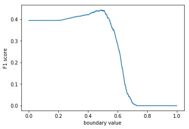

```python
boundary_candidates=np.linspace(0.,1.,1000)

F1_curve=[f1_score(ytrain,predictions_test>boundary) for boundary in boundary_candidates]
plt.plot(boundary_candidates,F1_curve)
plt.xlabel("boundary value")
plt.ylabel("F1 score")
best_boundary = boundary_candidates[np.array(F1_curve) == max(F1_curve)]
print(best_boundary)
```

# Predicted outcome distribution for unlabeled data predictions

```python
cm = confusion_matrix(ytrain,predictions_test>float(best_boundary))
cm=cm / float(cm.sum())
print(pd.DataFrame(cm,columns = ["pred no pizza","pred pizza"],index= ["no pizza","pizza"]))
print("\naccuracy:", (cm*np.eye(2)).sum())
```

```
          pred no pizza  pred pizza
no pizza       0.434901    0.319059
pizza          0.084653    0.161386

accuracy: 0.5962871287128713
```

# Predict values for unlabeled data

```python
# use test data
unlabeled_data = pd.read_json("C:\\Users\\Michael\\PycharmProjects\\pizza_challange\\test.json")

print(unlabeled_data.shape)
# make lower and count len text
unlabeled_data["request_text_lower"]=unlabeled_data["request_text_edit_aware"].apply(lambda x: x.lower())
unlabeled_data["request_title_lower"]=unlabeled_data["request_title"].apply(lambda x: x.lower())
unlabeled_data["request_title_lower"]=unlabeled_data["request_title"].apply(lambda x: x.lower())
unlabeled_data["request_text_n_letter"]=unlabeled_data["request_text_lower"].apply(len)


# detect words in text
for word_list, colname in [[dog_words,"contains_dog_words"],
                           [cat_words,"contains_cat_words"],
                           [child_words,"contains_child_words"],
                           [reciprocity_words,"contains_reciprocity_words"],
                           [hunger_words,"contains_hunger_words"],
                           [money_words, "contains_money_words"],
                           [emoticon_words, "contains_emoticon_words"],
                           [photos, "contains_photos"],
                           [links, "contains_links"]]:

    re_string = "|".join(word_list)
    print(re_string)
    unlabeled_data[colname] = unlabeled_data["request_text_lower"].str.contains(re_string)
    print(unlabeled_data[colname].sum())


# detect US places
with open("C:\\Users\Michael\\PycharmProjects\\pizza_challange\\common_US_place_names.txt") as fh:
    list_of_us_placenames = [x.strip() for x in fh.readlines()]

list_of_us_placenames = [re.escape(placename.lower()) for placename in list_of_us_placenames if len(placename) >2 ]# filter out any string that is short

us_in_title = unlabeled_data["request_title_lower"].str.contains(re_us_placenames)
us_in_text = unlabeled_data["request_text_lower"].str.contains(re_us_placenames)
unlabeled_data["requester from us"] = us_in_title | us_in_text

# instert n letter
request_id=unlabeled_data["request_id"]

unlabeled_data = unlabeled_data[[
                     "request_text_n_letter",
                     "requester_number_of_subreddits_at_request",
                     "contains_dog_words",
                     "contains_cat_words",
                     "contains_child_words",
                     "contains_reciprocity_words",
                     "contains_money_words",
                     "contains_photos",
                     "contains_links",
                     "unix_timestamp_of_request",
                     "requester from us",
                     "requester_upvotes_minus_downvotes_at_request",
                     "requester_account_age_in_days_at_request"]]

classifier_trained_all_train_data = RandomForestClassifier(max_depth=4,
                                                         class_weight="balanced",n_estimators =30).fit(xtrain, ytrain)


gets_pizza_pred = classifier_trained_all_train_data.predict_proba(unlabeled_data)>best_boundary
output= pd.Series(gets_pizza_pred[:,1],index = np.array(request_id))

output.to_csv("output_pizza_challange")
```

```
(1631, 17)
dog|pup|mutt|canine
43
cat|kitten|kitty|puss
173
baby|child|kid|son|daughter|infant|teenager|toddler|pregnant|pregger
254
pay it forward|return the fav
194
hungry|starv|eaten since|food since
233
pay|funds|bills|afford|dollar|coin|the means for|income|salary|check|employed|\$|poor|broke|paid
893
\:\)|\:\(
161
imgur
61
http
109
```

# Further work :

## Features:

Split subreddits into e.g.: general (askreddit, IMA ...), funny (funny, dankmemes, deepfriedmemes ...), news (worldnews / news ...) nsfw, activist

Time of day/day of week of post?

Feature exploration using random forrest

```
- using single words and / or ngrams?
```

Gender / sexual preference of requester

## Questions :

Are the subreddit rules recent (and why do they have so little predictive power)?

Is the model for predicting new posts outcomes? If so, the historical data (and specifically the request time) parameter may not be as predictive as shown here.

Why are repeat requests absent?